# RNA, protein and cell state

What does a correlation measure?

A journal club on biological variation, measurement accuracy and same-cell proteomics

Historical evidence and Thielert et al., bioRxiv v1, August 2026

## Three different RNA–protein correlations

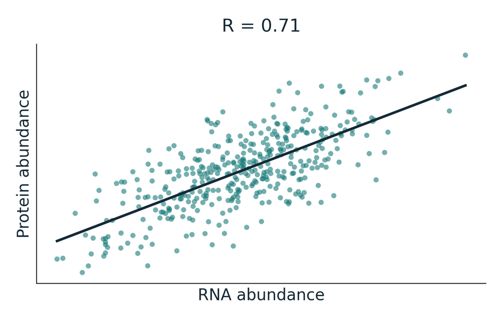

Across genes

One dot = one gene  
Are abundant RNAs associated with abundant proteins?

Across cells

One dot = one cell  
For a fixed gene, do RNA and protein rise and fall together?

Across conditions

One dot = one condition  
Do RNA changes predict protein changes or later responses?

Always ask what each point on the plot stands for.

Illustrative scatters, not paper data. A distinction used throughout this journal club.

## 1999: the abundance range changes the correlation

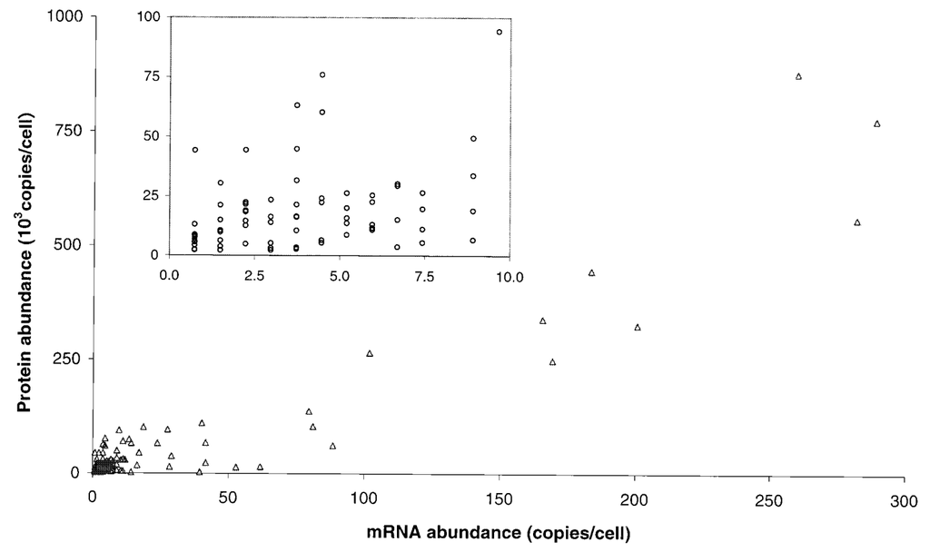

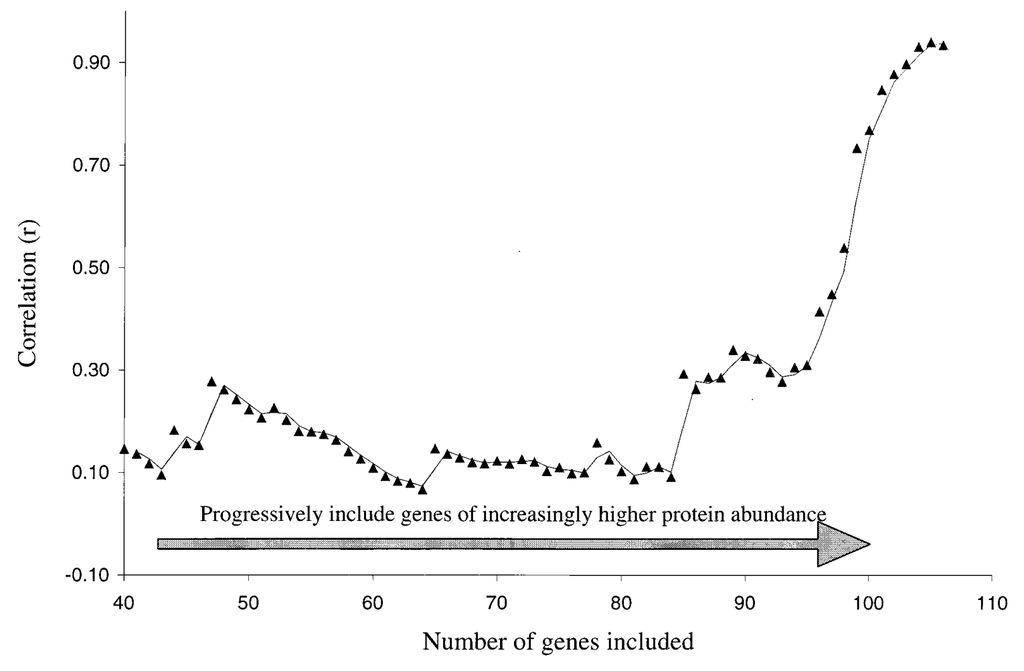

106 genes: r = 0.935  
Low-RNA subset: r = 0.356

A companion paper also questioned the accuracy of the low-abundance measurements.

A handful of highly abundant genes made the overall relationship look stronger than it really was for most genes.

Gygi et al. Mol Cell Biol (1999). doi:10.1128/MCB.19.3.1720 • Figures 5 and 6

## 2002: two glowing tags separate two kinds of noise

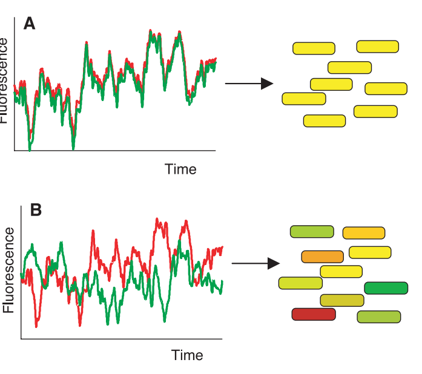

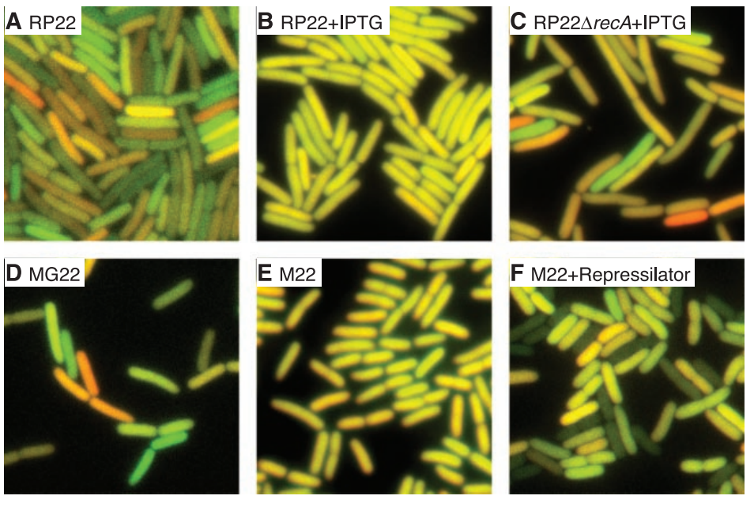

Shared ups and downs

Whatever is happening in the whole cell affects both tags together.

Independent ups and downs

The two copies of the same gene can still behave differently inside one cell.

Biological noise and measurement error need to be told apart.

Elowitz et al. Science (2002). doi:10.1126/science.1070919 • Figures 1 and 2

## 2006: how long a protein survives changes the link

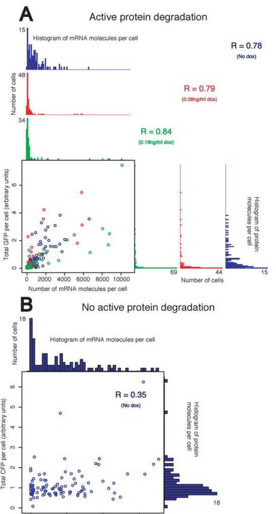

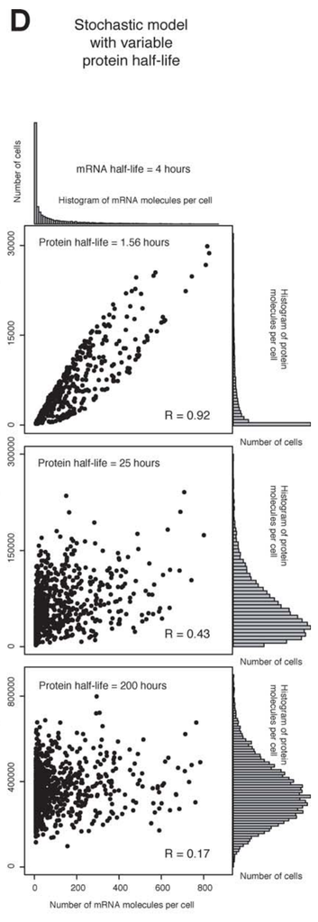

What was measured

A protein that gets broken down quickly: stronger link to RNA.  
A stable protein: weaker link to RNA.

A simple model

A longer-lived protein smooths out short bursts of RNA.

How long a protein survives changes how tightly it tracks its RNA.

Raj et al. PLoS Biol (2006). doi:10.1371/journal.pbio.0040309 • Figure 7A,B,D

## 2010: the same weak link, seen without a mass spectrometer

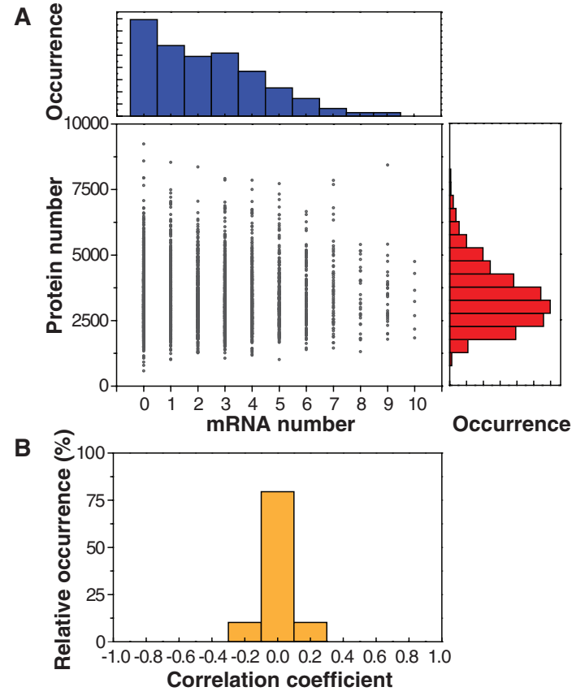

One gene, many cells

tufA: r ≈ 0.01 (5,447 cells)

Measured side by side

Glowing protein and RNA spots, counted in the same cells at the same moment.

Even measured directly, side by side, RNA and protein barely moved together for this gene.

Taniguchi et al. Science (2010). doi:10.1126/science.1188308 • Figure 4

## 2011–2014: the same kind of data, two different conclusions

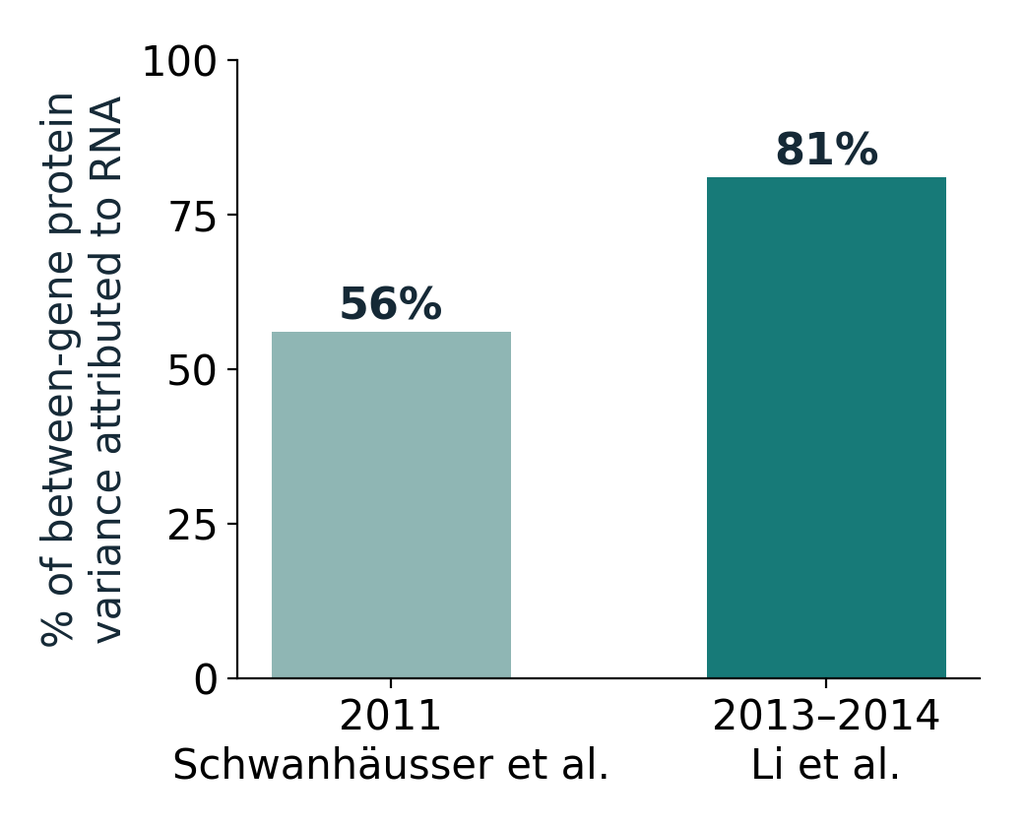

2011: a first global estimate

Combining protein amounts with how fast RNA and protein are made and broken down, this analysis attributed about 56% of the between-gene differences in protein levels to differences in RNA.

2013–2014: the numbers move

A correction, plus a new analysis using more carefully measured proteins, pushed that estimate up to about 81%.

The same kind of data can support different conclusions, depending on how the measurement is calibrated.

This is about average differences between genes — not about whether RNA and protein move together inside one cell.

Schwanhäusser et al. Nature (2011), doi:10.1038/nature10098. Li et al. PeerJ (2014), doi:10.7717/peerj.270

## 2015: noise and missing values can hide a true correlation

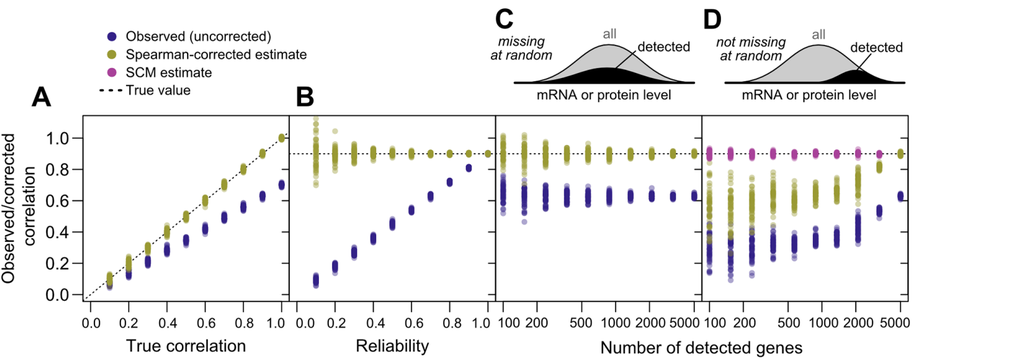

How precise the measurement is changes the correlation you can see.

Correcting for this means making assumptions about which values go missing, and about whether RNA and protein share some of the same errors.

A true, strong relationship can look weak if the measurement is imprecise.

Csárdi et al. PLoS Genet (2015). doi:10.1371/journal.pgen.1005206 • Figure 3 (simulations)

## 2026: deep RNA and protein measurements from one cell

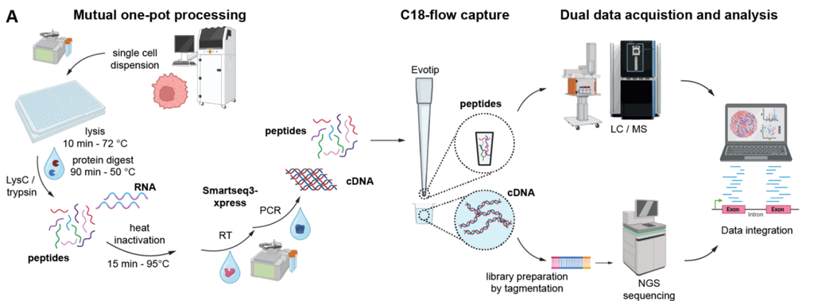

Tested in growing cancer cells, and in mouse stem cells moving through early development.

Its biggest strength: the RNA and the protein come from the very same single cell.

Thielert et al. bioRxiv v1 (2026). doi:10.64898/2026.08.25.746940 • Figure 1A

## More detections is not the same as more accuracy

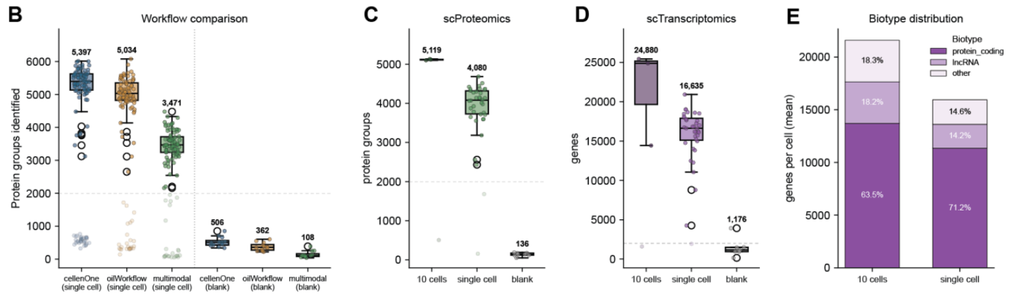

About 4,080 proteins and 16,635 genes found per cell.

Still missing: testing the method on a sample where the right answer is already known, to see how much error it adds.

Finding more things is not the same as measuring them more accurately.

Thielert et al. bioRxiv v1 (2026). doi:10.64898/2026.08.25.746940 • Figure 1B–E

## Why two very different correlation numbers are both right

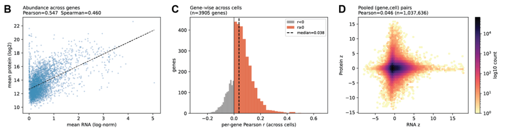

Comparing genes to each other

A clear relationship (r ≈ 0.55)

Comparing one gene across cells

Almost no relationship (r = 0.038)

Both numbers are correct — they just answer different questions.

Thielert et al. bioRxiv v1 (2026). doi:10.64898/2026.08.25.746940 • Figure S3B–D

## Well-known marker genes behave better than genes overall

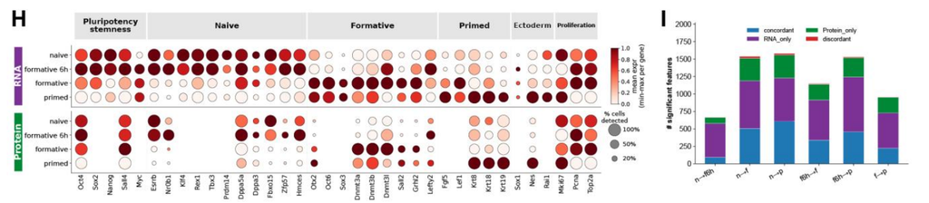

Well-known markers: r = 0.32  
All genes together: r = 0.044

Detection and statistical power differ between the two methods.

Many changes between cell states show up only in RNA, not protein — not necessarily because only one of them truly changed.

Thielert et al. bioRxiv v1 (2026). doi:10.64898/2026.08.25.746940 • Figure 3H,I

## Only about a third of genes change RNA and protein at the same time

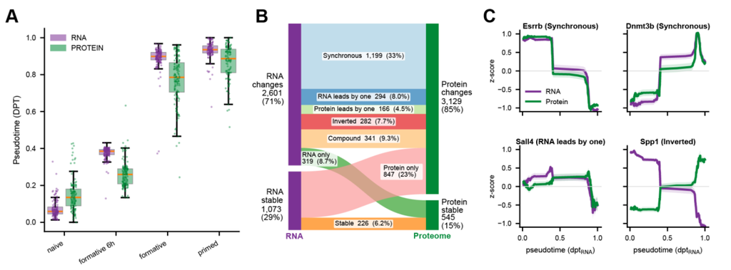

RNA and protein often carry different, complementary information.

This “timing” comes from comparing different cells to each other, ordered by how far along they are.

It is not a stopwatch measurement inside one cell — it is an ordering built by comparing many different cells.

Thielert et al. bioRxiv v1 (2026). doi:10.64898/2026.08.25.746940 • Figure 4A–C

## The main claim: RNA levels swing about five times more than protein

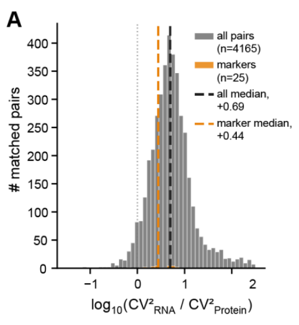

What was found

Protein levels vary less, relative to their own average, than RNA levels do.

One explanation

Proteins stick around longer than RNA, so they smooth out short-lived ups and downs.

How much of this gap is real biology, and how much comes from how each molecule is measured?

Thielert et al. bioRxiv v1 (2026). doi:10.64898/2026.08.25.746940 • Figure 5A

## Protein’s overall pattern needs far fewer cells to see clearly

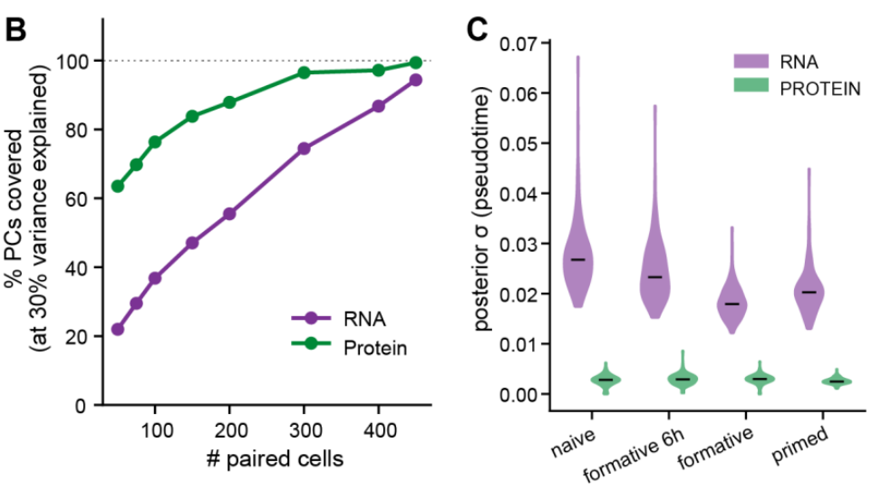

These uncertainty estimates still need to be checked against independent evidence.

Protein’s overall pattern is simpler, so a small sample already shows most of it.

Thielert et al. bioRxiv v1 (2026). doi:10.64898/2026.08.25.746940 • Figure 5B,C

## What can make two linked things look unlinked?

What you measure = the true amount, plus whatever the measurement adds or misses.

Repeatability

How similar the answer is if you measure the same sample again. Random noise alone can make things look more scattered than they really are.

Accuracy

Whether the measurement gets the real number right. It can be very repeatable and still be wrong by the same amount every time.

Real biological difference

The true differences between cells, once you account for how the measurement responds and where it slips.

A low correlation, on its own, does not prove the measurement is accurate — or that the biology is simple.

A general way of thinking about measurement, used on the next two slides.

## Seeing it happen: perfect coupling, then add noise

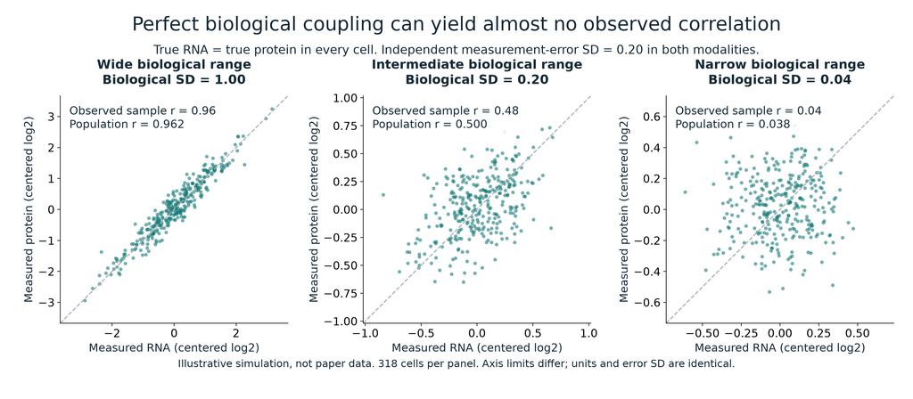

Protein is built to be an exact mirror of RNA in every single cell, no exceptions. Only the amount of natural cell-to-cell difference changes from panel to panel; the measurement noise stays the same.

Cells differ a lot: r ≈ 0.96 — cells differ a little: r ≈ 0.50 — cells barely differ: r ≈ 0.04

The link between RNA and protein never changed. Only how much the cells truly differed from one another, compared to the noise, changed.

An illustrative exercise for this journal club, not a re-analysis of Thielert et al. The same fixed amount of measurement noise is added in every panel.

## More cells sharpen the estimate — they don’t erase the noise

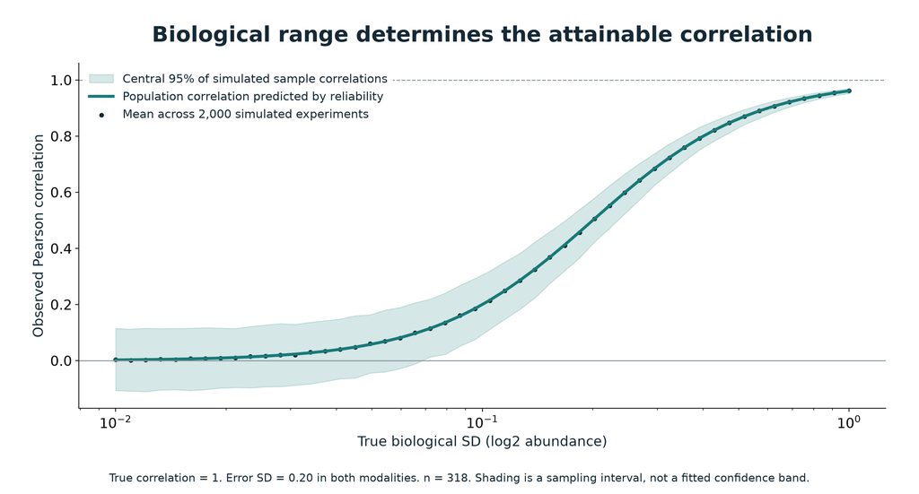

Repeating the same noisy measurement on many more cells gives a far more confident estimate of the correlation.

A bigger study answers “how sure are we of this number?” It cannot answer “how much is hidden by noise?”

The estimate still settles on the same low number — set by the noise, not by how many cells were measured.

An illustrative exercise for this journal club, continued from the previous slide.

## A tempting criticism that turns out not to apply

What the paper actually did

This comparison used real, measured protein values — not values filled in by guesswork — and only counted cell states with at least 15 cells.

What’s still worth checking

The exact way the numbers were calculated, whether raw RNA read counts change anything, and how sensitive the result is to the detection cutoff.

Filling in missing values is a real concern elsewhere in this paper — but it is not the explanation for this particular result.

Thielert et al. bioRxiv v1 (2026). doi:10.64898/2026.08.25.746940 • Methods pp. 26–28 and Figure 5

## Experiments that could tell biology and measurement apart

Known amount

Measuring the very same prepared sample over and over shows how much noise the process itself adds.

Known differences

Mixing known amounts together, or diluting step by step, tests whether the method reports real changes accurately.

Careful analysis

Looking only at genes measured well by both methods, using raw numbers, and checking different counting rules.

An outside check

Comparing against a different method, or against cell states defined without RNA or protein at all.

Good controls compare the method to something other than itself.

Proposed checks and sensitivity analyses, not experiments the authors are known to have run.

## Discussion: what does the evidence establish?

Same-cell profiling reveals complementary RNA and protein patterns, and protein’s lower measured variability fits with the idea that it is more stable than RNA.

How much of that difference is real biology, and how much comes from how each method measures and processes its signal?

Which single control would most change your confidence?

Thielert et al. bioRxiv v1 (2026). doi:10.64898/2026.08.25.746940; historical sources on following slides.

## References: history and measurement

**Gygi et al. (1999)** Correlation between protein and mRNA abundance in yeast  
10.1128/MCB.19.3.1720

**Futcher et al. (1999)** A sampling of the yeast proteome  
10.1128/MCB.19.11.7357

**Elowitz et al. (2002)** Stochastic gene expression in a single cell  
10.1126/science.1070919

**Raj et al. (2006)** Stochastic mRNA synthesis in mammalian cells  
10.1371/journal.pbio.0040309

**Taniguchi et al. (2010)** Quantifying E. coli proteome and transcriptome with single-molecule sensitivity in single cells  
10.1126/science.1188308

Original paper figures retain panel labels. Sources and interpretation notes accompany each slide.

## References: calibration, simulation and the current preprint

**Schwanhäusser et al. (2011)** Global quantification of mammalian gene expression control. Nature.  
10.1038/nature10098 (correction in 2013)

**Li, Bickel & Biggin (2014)** System wide analyses have underestimated protein abundances and the importance of transcription in mammals. PeerJ.  
10.7717/peerj.270

**Csárdi et al. (2015)** Accounting for experimental noise reveals that mRNA levels, amplified by post-transcriptional processes, largely determine steady-state protein levels in yeast.  
10.1371/journal.pgen.1005206

**Thielert et al. (2026)** In the same cell, the proteome defines cellular state and the transcriptome marks transitions. bioRxiv v1  
10.64898/2026.08.25.746940

**This journal club** Perfect coupling, variable noise: a simulation illustrating classical measurement-error attenuation (`simulate.py`, fixed seed 20261116)

The supplied preprint is version 1, posted 26 August 2026, and has not been peer reviewed.